# Clasificación: Trabajo de evaluación

Lucía Belén González Giaimo

El fichero `customer.csv` contiene información sobre los clientes de una determinada compañía de telecomunicaciones. Concretamente, se tiene información sobre algunos aspectos demográficos y los servicios/productos que tiene contratado. En la última columna se indica si el cliente en cuestión abandona la compañía en el mes siguiente. El objetivo del trabajo es construir un clasificador que permita predecir, a partir de la información contenida en el fichero, si el cliente va a abandonar la compañía en el siguiente mes.

## Resumen

### Preprocesamiento

El preprocesamiento realizado incluyó:

- La eliminación de la variable `customerID`
- La conversión del tipo de la variable `seniorCitizen` de ‘integer’ a ‘factor’.
- La recodificación de las variables relacionadas al servicio de teléfono (unificación de categorías ‘No’ y ‘No phone service’).
- La recodificación de las variables relacionadas al servicio de internet (unificación de categorías ‘No’ y ‘No internet service’).
- La transformación de las variables categóricas a dummy.
- La división del dataset en Train y Test.

### Clasificadores probados

Los clasificadores que se probaron fueron:

- Árbol de decisión (rpart)
- Random Forest
- Support Vector Machine (kernel: radial)
- Linear Discriminant Analysis
- AdaBoost

### Conclusiones

- El modelo que más eficacia tiene ,medida en términos de `Accuracy`, fue `adaBoost` (**0.805**), seguido por `Random Forest` (**0.797**) y `svmRadial` (**0.795**). Por último se encuentran `LDA` (**0.788**) y `rpart` (**0.785**).
- Las variables de mayor importancia son: `tenure`, `InternetService.Fiber.optic`, `TotalCharges`, `Contract.Two.Year`, `PaymentMethod.Electronic.check` y `MonthlyCharges`.
- Realizar un proceso de selección de variables reduce el tiempo de entrenamiento pero no mejora la performance de los modelos.
- Realizar un proceso de balanceo en el dataset de entrenamiento (upsampling) empeora la performance en términos de Accuracy y la mejora en términos de Sensibilidad.

## 1. Análisis descriptivo de los datos

**Lectura de los datos**

```r
customer <- read.csv("customer.csv", stringsAsFactors = TRUE)
```

**Cabecera del fichero**

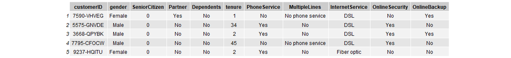

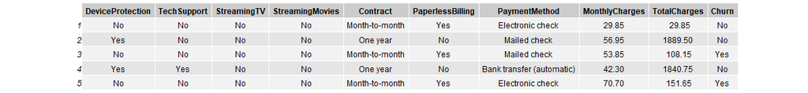

Se observa que hay 20 variables predictoras y 1 a predecir (`Churn`).

Hay variables:

- demográficas: `gender`, `SeniorCitizen`, `Partner` y `Dependents`.
- relacionadas al cliente: `Contract`, `PaperlessBilling` y `PaymentMethod`.
- relacionadas al servicio de teléfono: `PhoneService` y `MultipleLines`.
- relacionadas al servicio de Internet: `InternetService`, `OnlineSecurity`, `OnlineBackup`, `DeviceProtection`, `TechSupport`, `StreamingTV` y `StreamingMovies`.

La variable `customerId` sirve solo para identificar a los clientes, por lo que no tiene poder predictivo.

**Estado general del dataset**

| variable | q_zeros | p_zeros | q_na | p_na | q_inf | p_inf | type | unique |
| --- | --- | --- | --- | --- | --- | --- | --- | --- |
| customerID | 0 | 0.00 | 0 | 0 | 0 | 0 | factor | 7032 |
| gender | 0 | 0.00 | 0 | 0 | 0 | 0 | factor | 2 |
| SeniorCitizen | 5890 | 83.76 | 0 | 0 | 0 | 0 | integer | 2 |
| Partner | 0 | 0.00 | 0 | 0 | 0 | 0 | factor | 2 |
| Dependents | 0 | 0.00 | 0 | 0 | 0 | 0 | factor | 2 |
| tenure | 0 | 0.00 | 0 | 0 | 0 | 0 | integer | 72 |
| PhoneService | 0 | 0.00 | 0 | 0 | 0 | 0 | factor | 2 |
| MultipleLines | 0 | 0.00 | 0 | 0 | 0 | 0 | factor | 3 |
| InternetService | 0 | 0.00 | 0 | 0 | 0 | 0 | factor | 3 |
| OnlineSecurity | 0 | 0.00 | 0 | 0 | 0 | 0 | factor | 3 |
| OnlineBackup | 0 | 0.00 | 0 | 0 | 0 | 0 | factor | 3 |
| DeviceProtection | 0 | 0.00 | 0 | 0 | 0 | 0 | factor | 3 |
| TechSupport | 0 | 0.00 | 0 | 0 | 0 | 0 | factor | 3 |
| StreamingTV | 0 | 0.00 | 0 | 0 | 0 | 0 | factor | 3 |
| StreamingMovies | 0 | 0.00 | 0 | 0 | 0 | 0 | factor | 3 |
| Contract | 0 | 0.00 | 0 | 0 | 0 | 0 | factor | 3 |
| PaperlessBilling | 0 | 0.00 | 0 | 0 | 0 | 0 | factor | 2 |
| PaymentMethod | 0 | 0.00 | 0 | 0 | 0 | 0 | factor | 4 |
| MonthlyCharges | 0 | 0.00 | 0 | 0 | 0 | 0 | numeric | 1584 |
| TotalCharges | 0 | 0.00 | 0 | 0 | 0 | 0 | numeric | 6530 |
| Churn | 0 | 0.00 | 0 | 0 | 0 | 0 | factor | 2 |

De la tabla se desprende que hay 7032 instancias y que no hay valores ausentes. También se puede apreciar que la mayoría de las variables son categóricas y que `SeniorCitizen` debería ser de tipo factor.

## 2. Análisis exploratorio de los datos

### 2.1 Análisis de la variable a predecir

Se puede ver que la clase a predecir se encuentra desbalanceada: mientras que un 73% de los clientes permanece con la compañía al mes siguiente, un 27% la abandona.

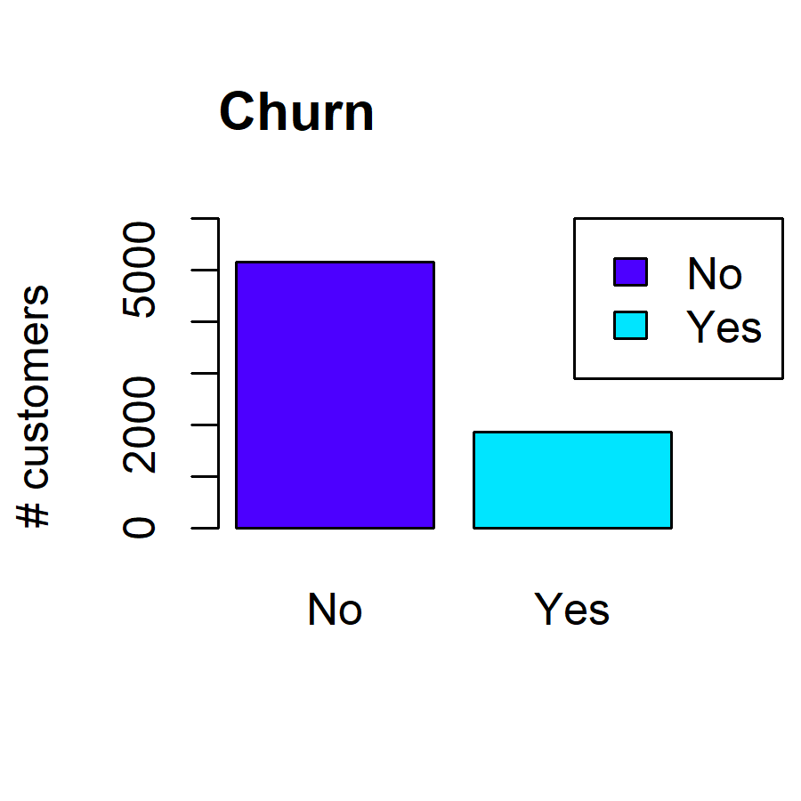

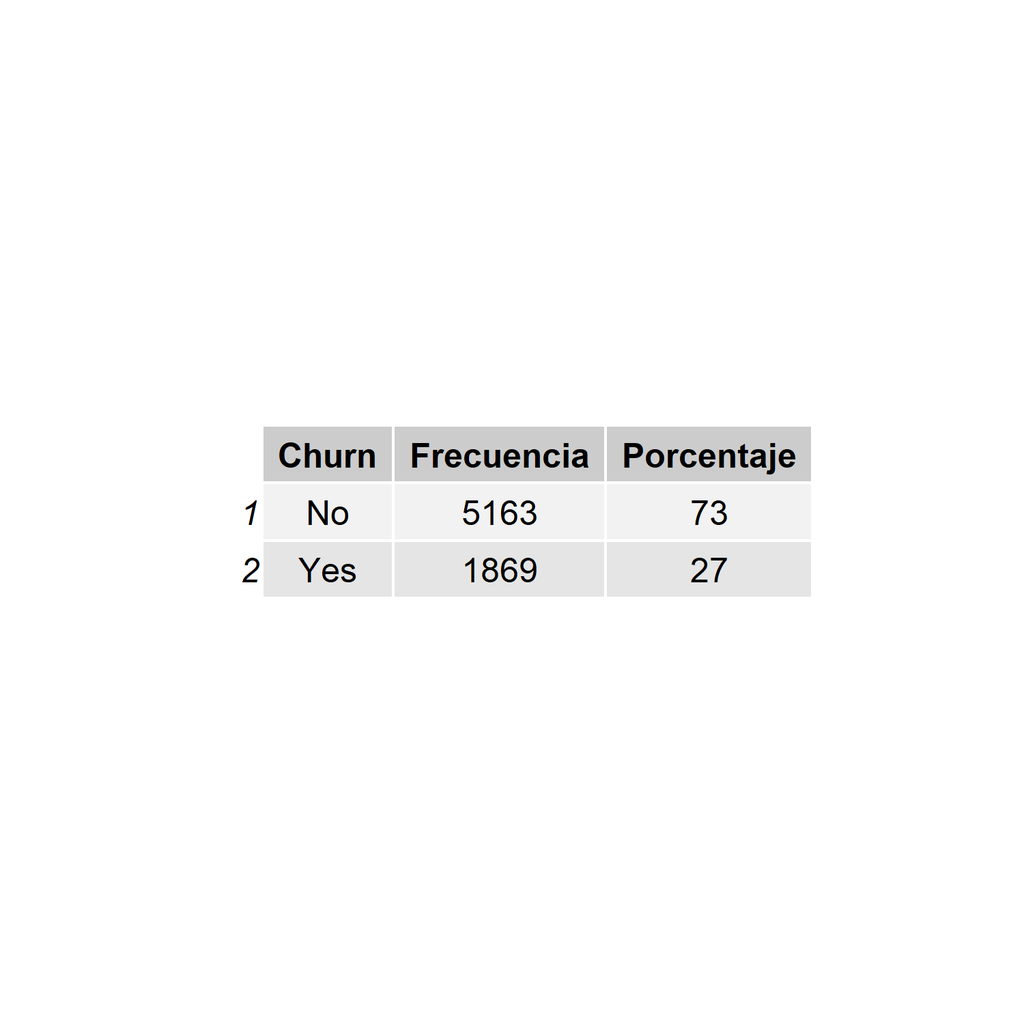

### 2.2 Análisis de las variables cuantitativas

Observando la distribución de la variable `tenure`, que representa la cantidad de meses que el cliente lleva con la compañía, se puede apreciar que los clientes con más antigüedad desertan menos que los clientes más nuevos. Además, la distribución tiene forma de “U”, hay muchos clientes nuevos y muchos clientes antiguos.

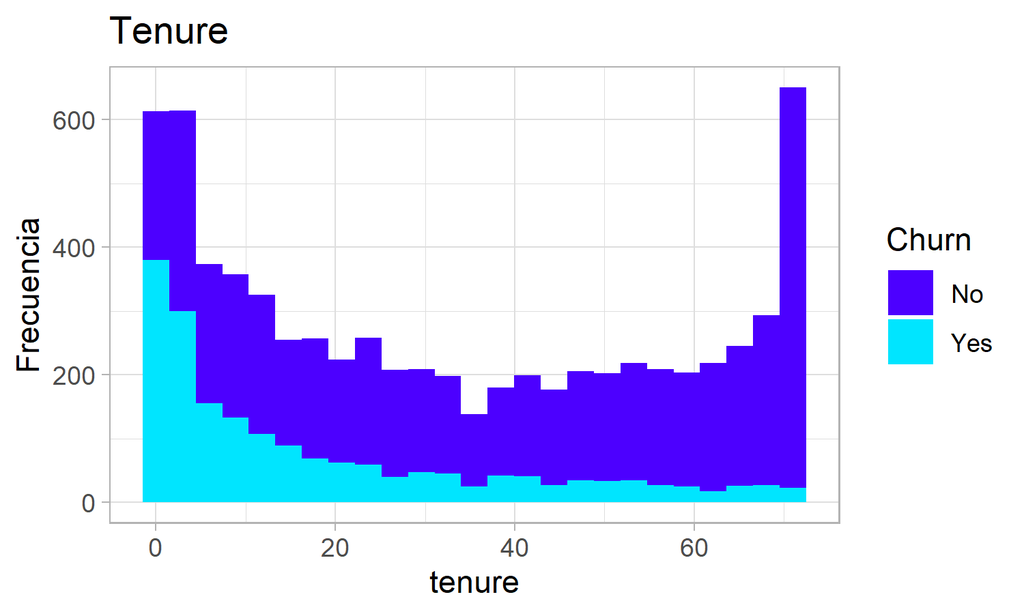

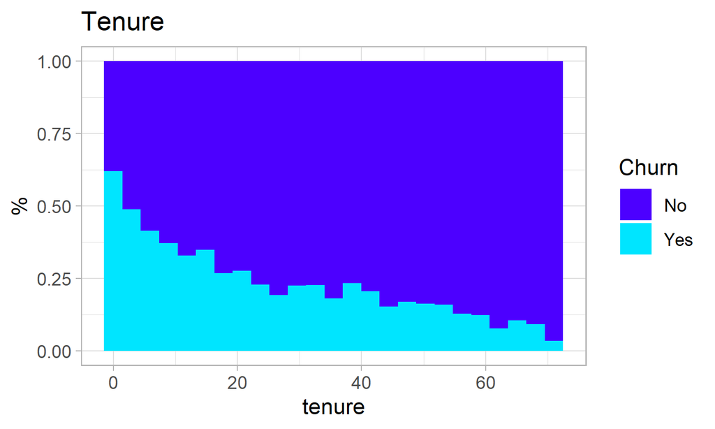

A diferencia de `tenure`, la distribución de la variable `MonthlyCharges`, que representa el monto de dinero que cada cliente pagó el último mes, no presenta un patrón claro con respecto a la vaiable `Churn` por lo que es de esperar que esta variable tenga un poder predictor menor que el de `tenure`.

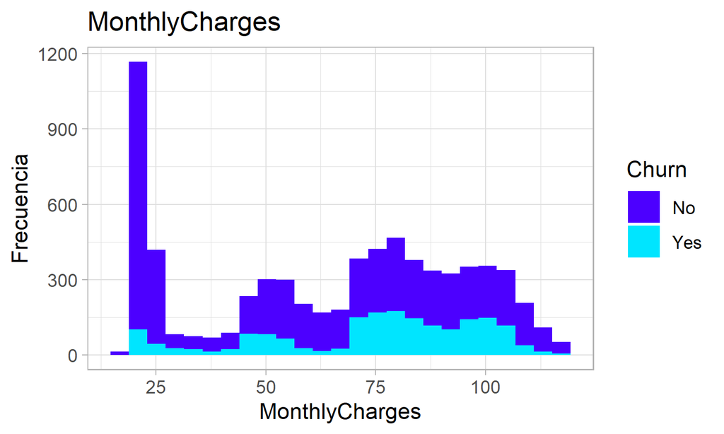

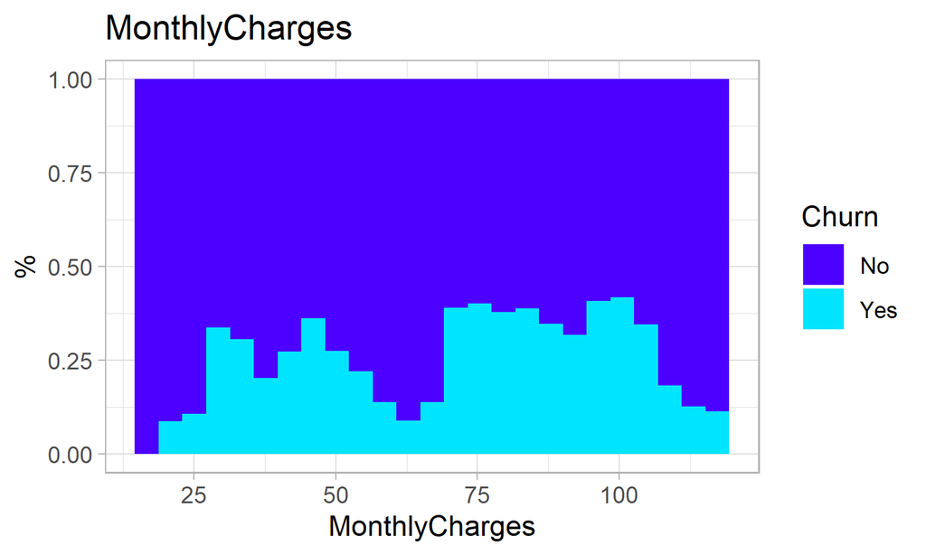

`TotalCharges` representa el monto de dinero total que pagó cada cliente. En cierta medida, está relacionada con `tenure` dado que es el resultado de sumar todas las cuotas mensuales que el cliente ha abonado a lo largo del tiempo. Al igual que `tenure`, se observa que los clientes que han pagado montos mayores, desertan menos que los clientes que han pagado montos menores. A diferencia de `tenure`, se observa que la mayoría de los clientes ha pagado poco dinero (la distribución no tiene forma de “U”).

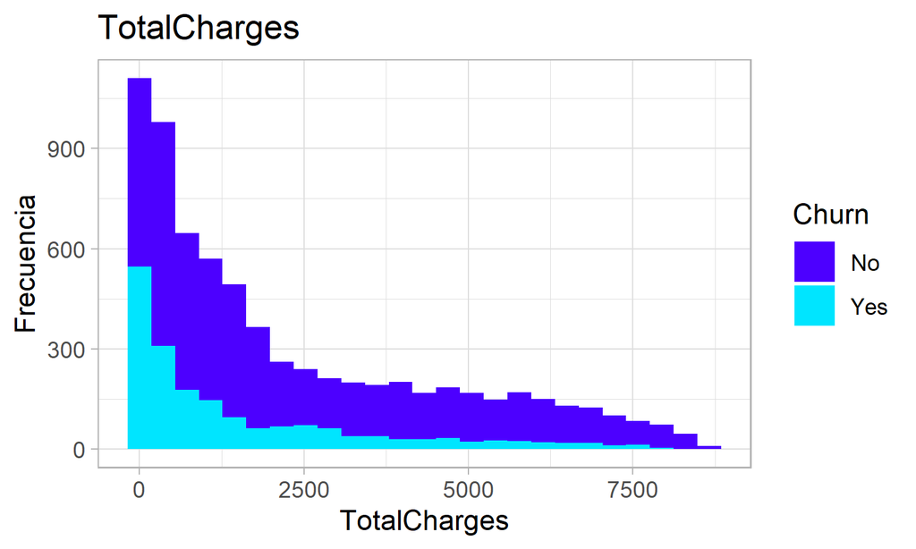

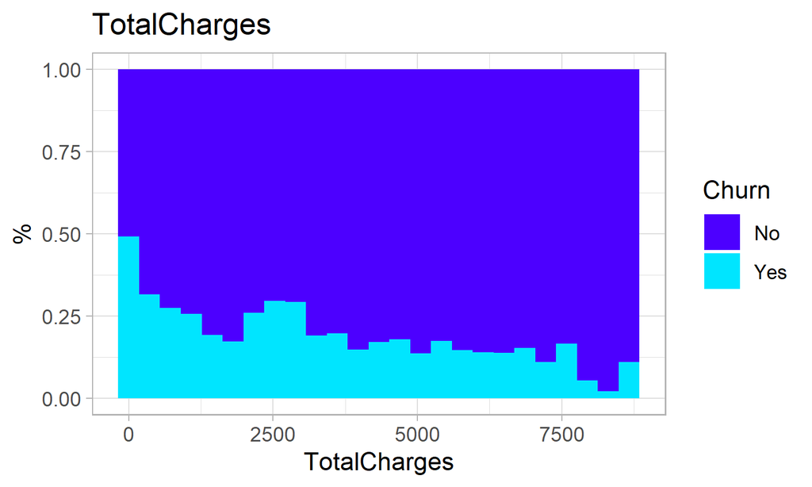

### 2.3 Análisis de variables categóricas

En los siguientes gráficos se muestra para cada clase de cada variable, la cantidad de clientes que abandonó y que no la compañía en el mes siguiente. En las tablas que acompañan a los gráficos se muestran las proporciones correspondientes.

#### 2.3.1 Variables demográficas

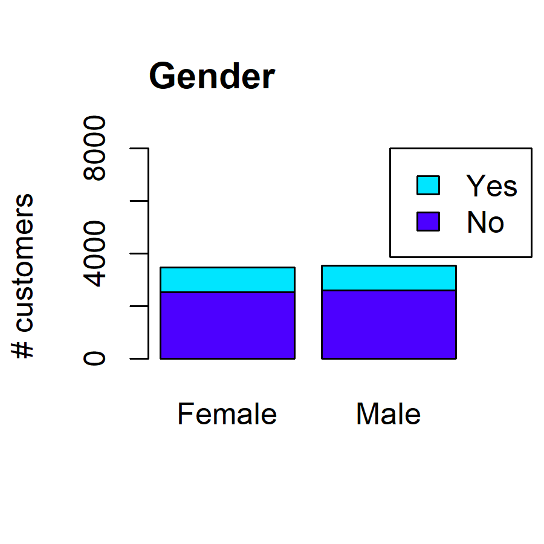

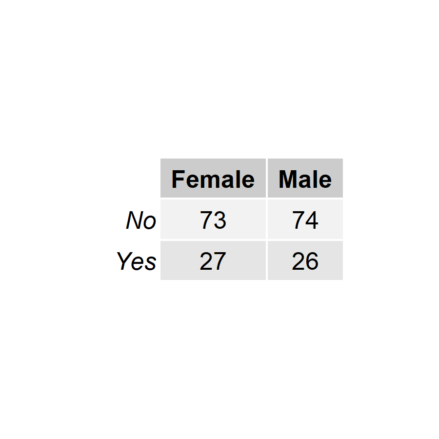

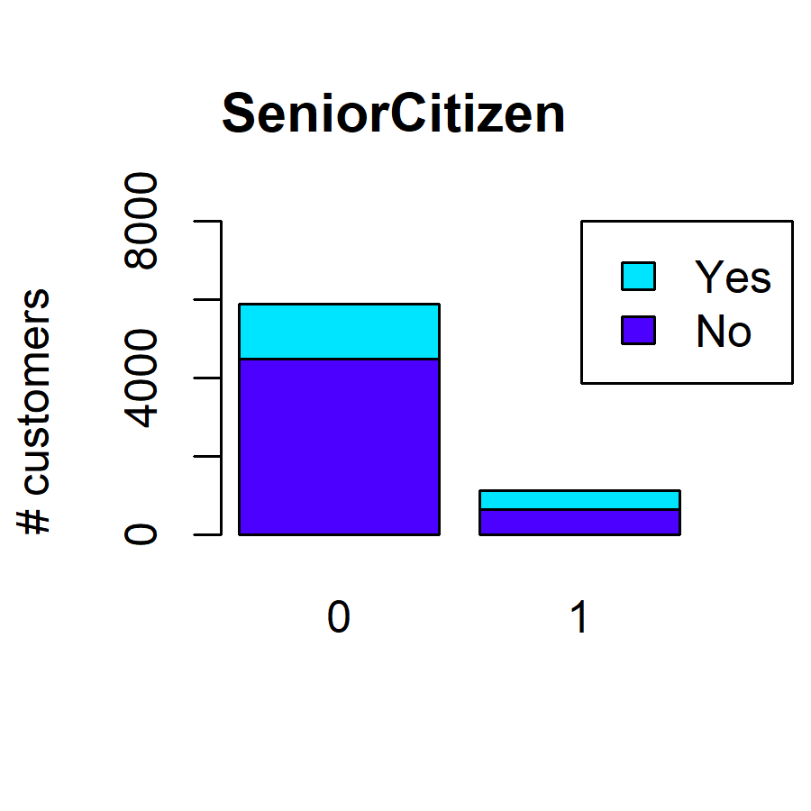

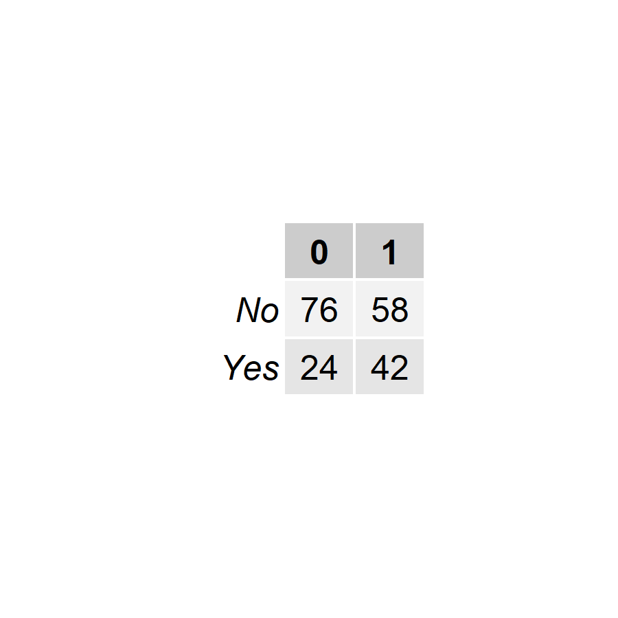

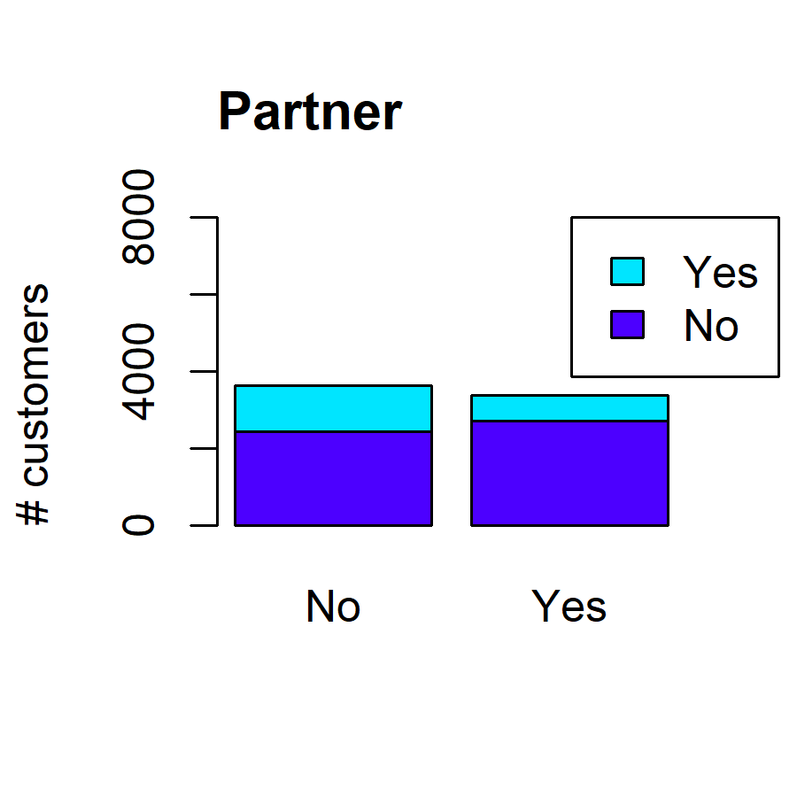

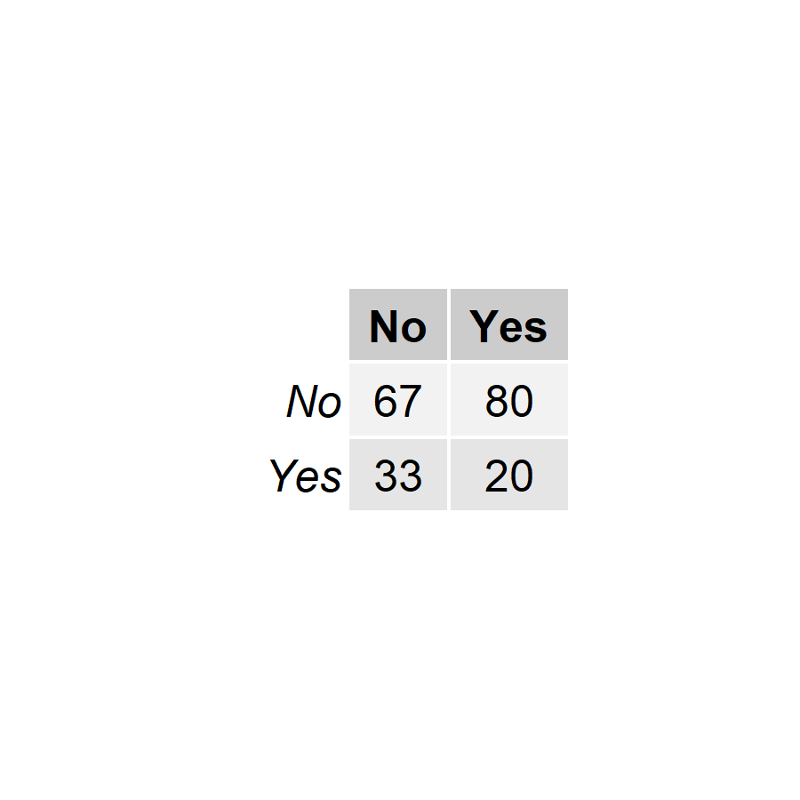

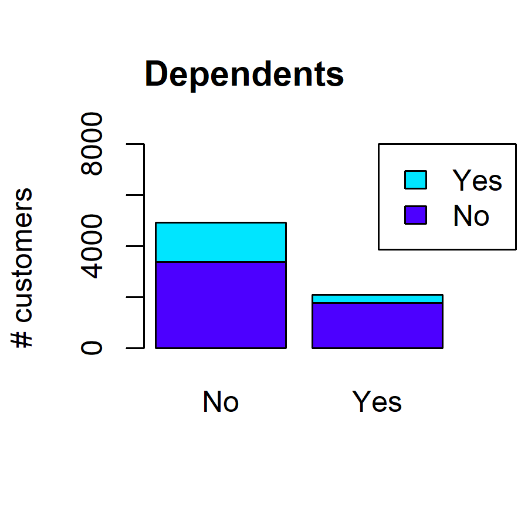

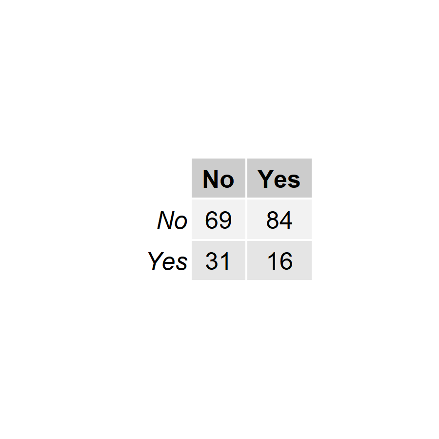

#### 2.3.2 Variables relacionadas con el cliente

- Vemos que los clientes que tienen un contrato mes-a-mes representan la clase mayoritaria y que además son los que poseen una tasa de abandono notablemente mayor (43%). Es de esperar que esta variable tenga un poder predictor alto.
- Los clientes `PaperLessBilling=Yes` poseen una tasa de abandono más alta (34%) que los clientes `PaperLessBilling=No` (16%).
- Los clientes que pagan a través de cheque electrónico desertan más que los clientes que pagan a través de otro método de pago.

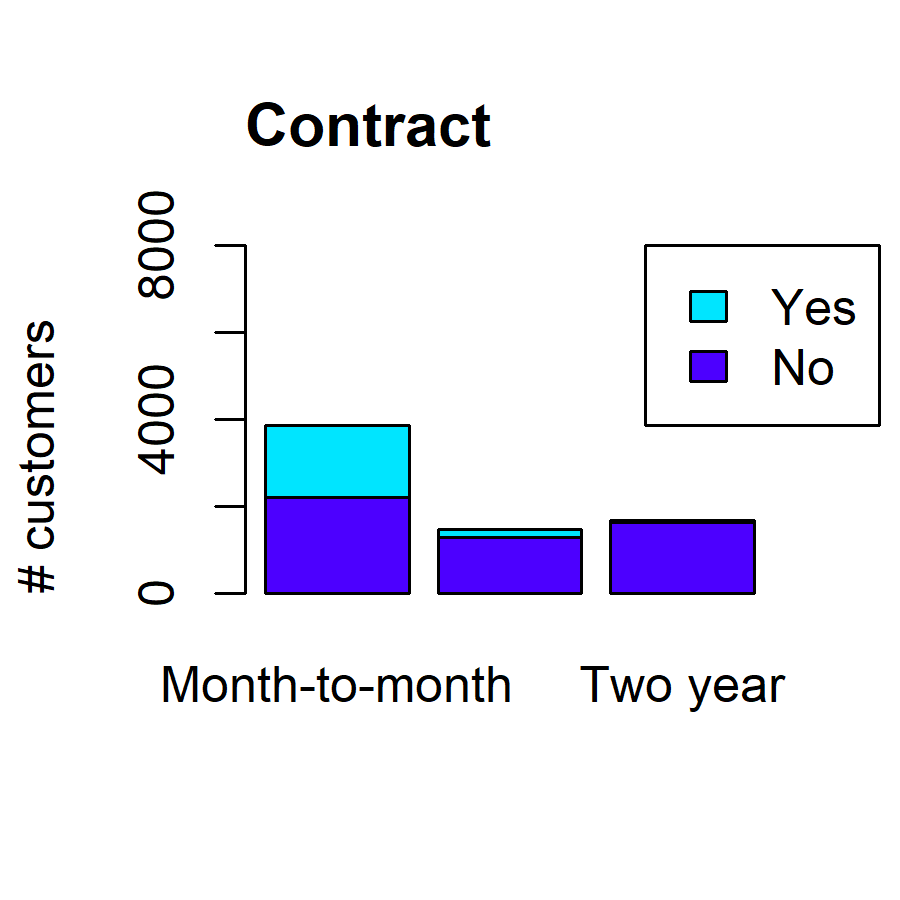

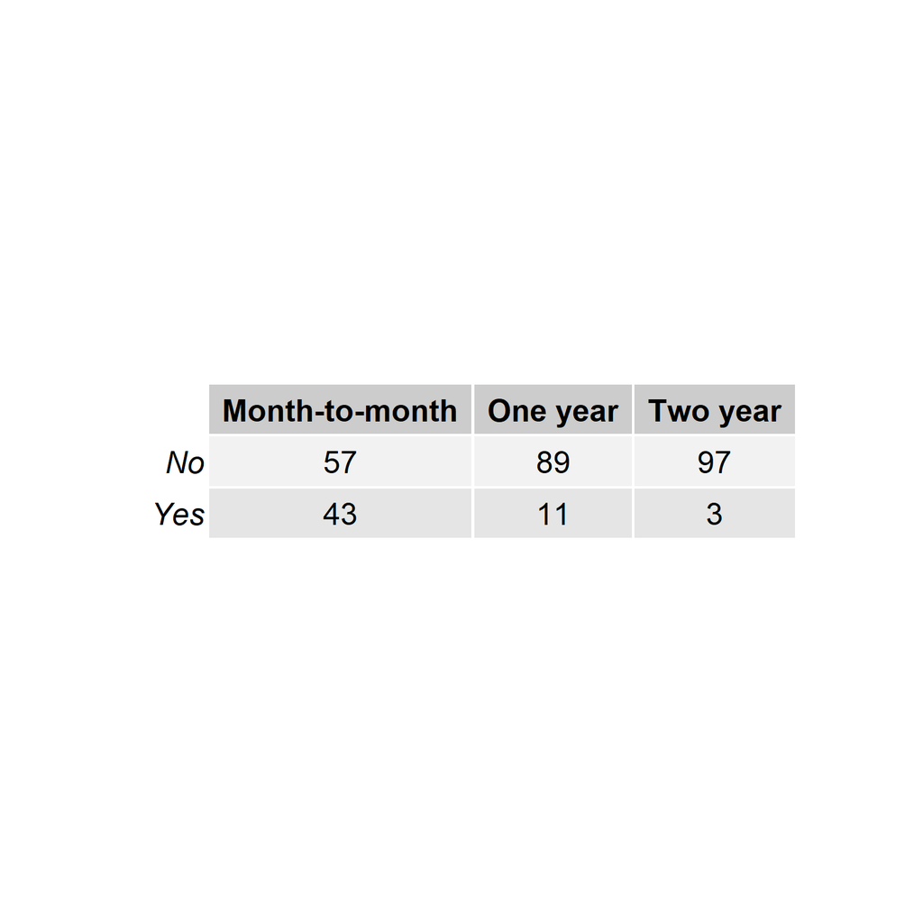

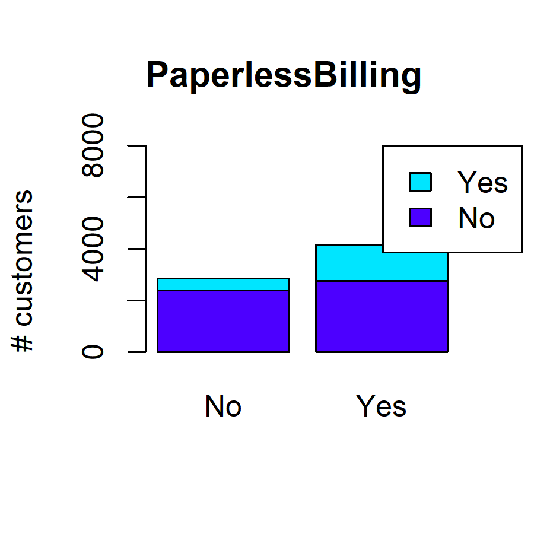

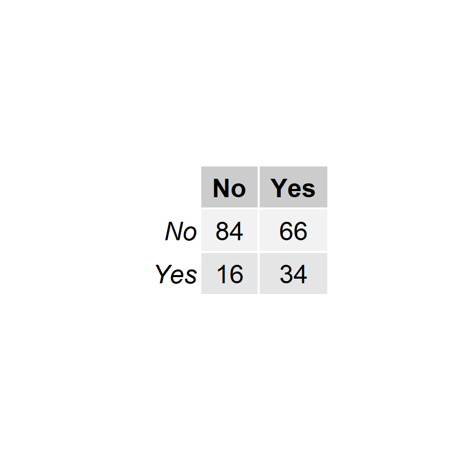

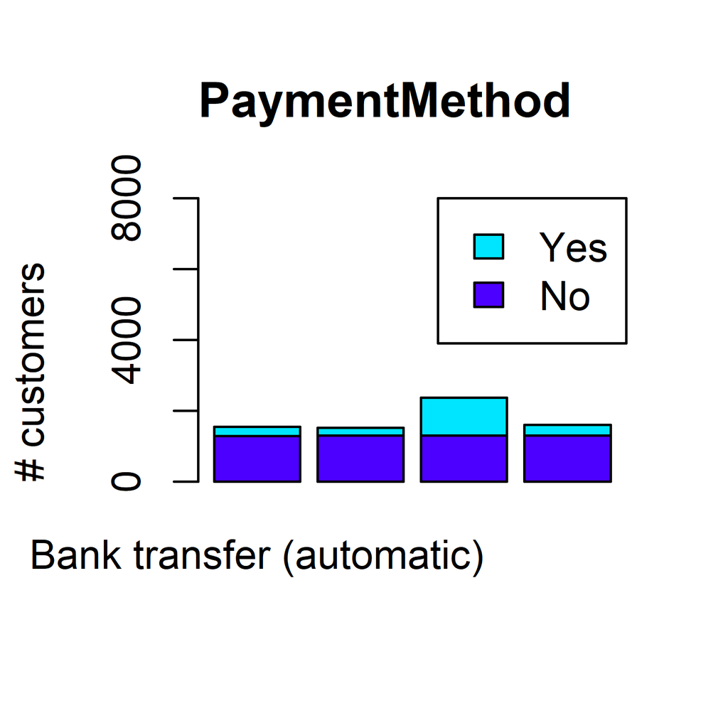

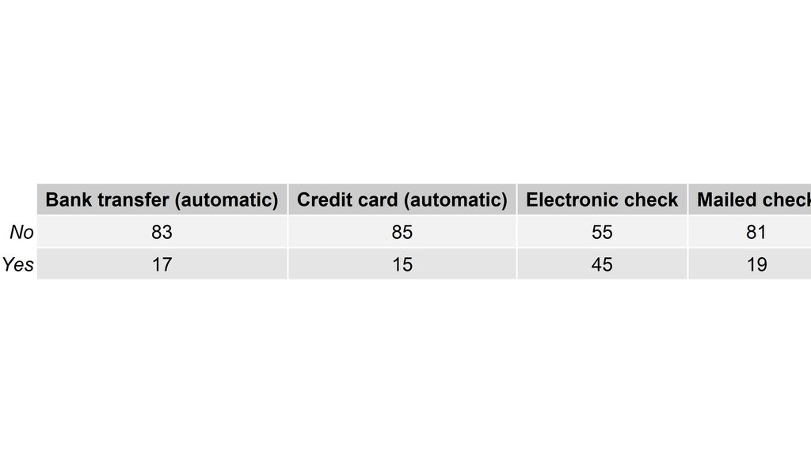

#### 2.3.3 Variables relacionadas al servicio de teléfono

- Se puede ver que la cantidad de personas que no contrata el servicio de teléfono es baja y que la proporción de desertores en las dos clases de la variable `PhoneService` es similar a la tasa de abandono general.
- En cuanto a los clientes que contratan múltiples líneas, se observa una tasa de abandono similar a la general.

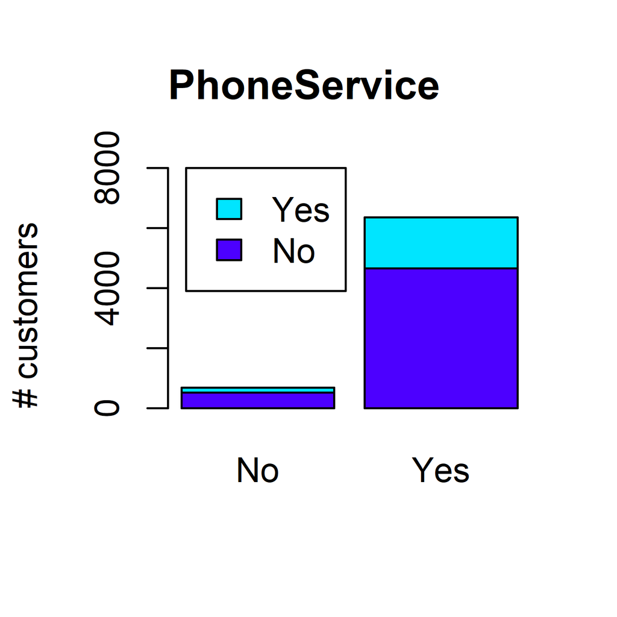

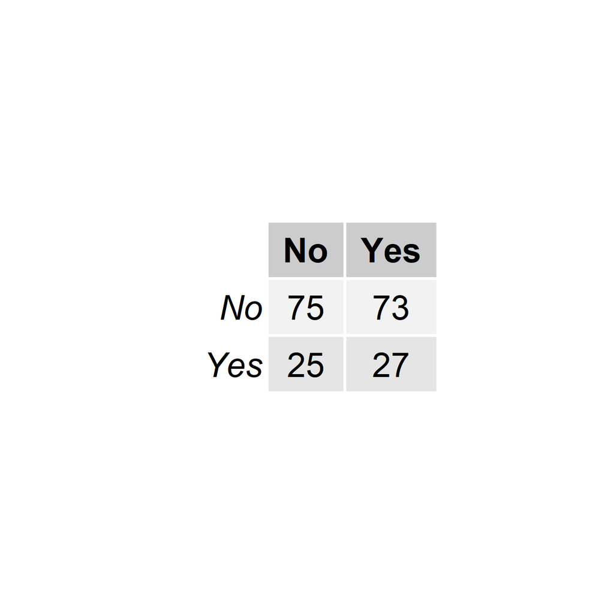

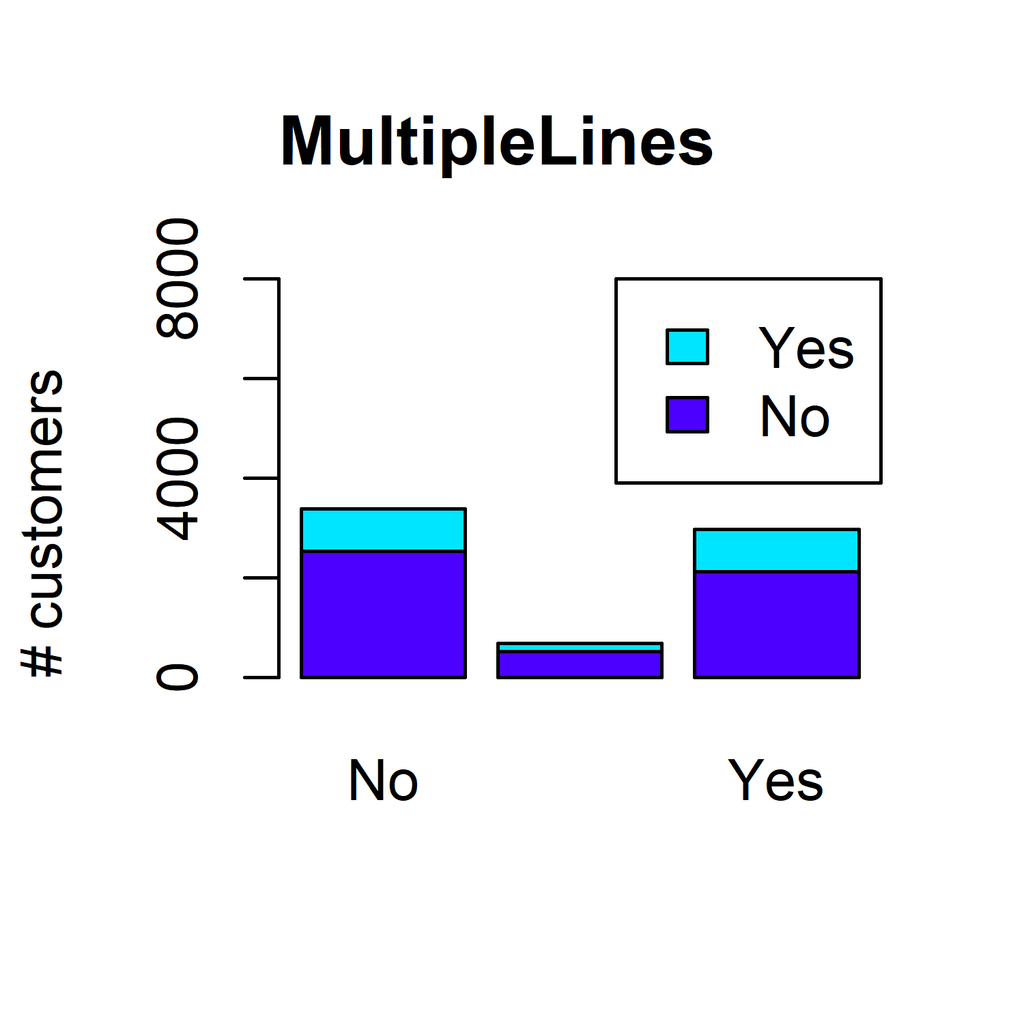

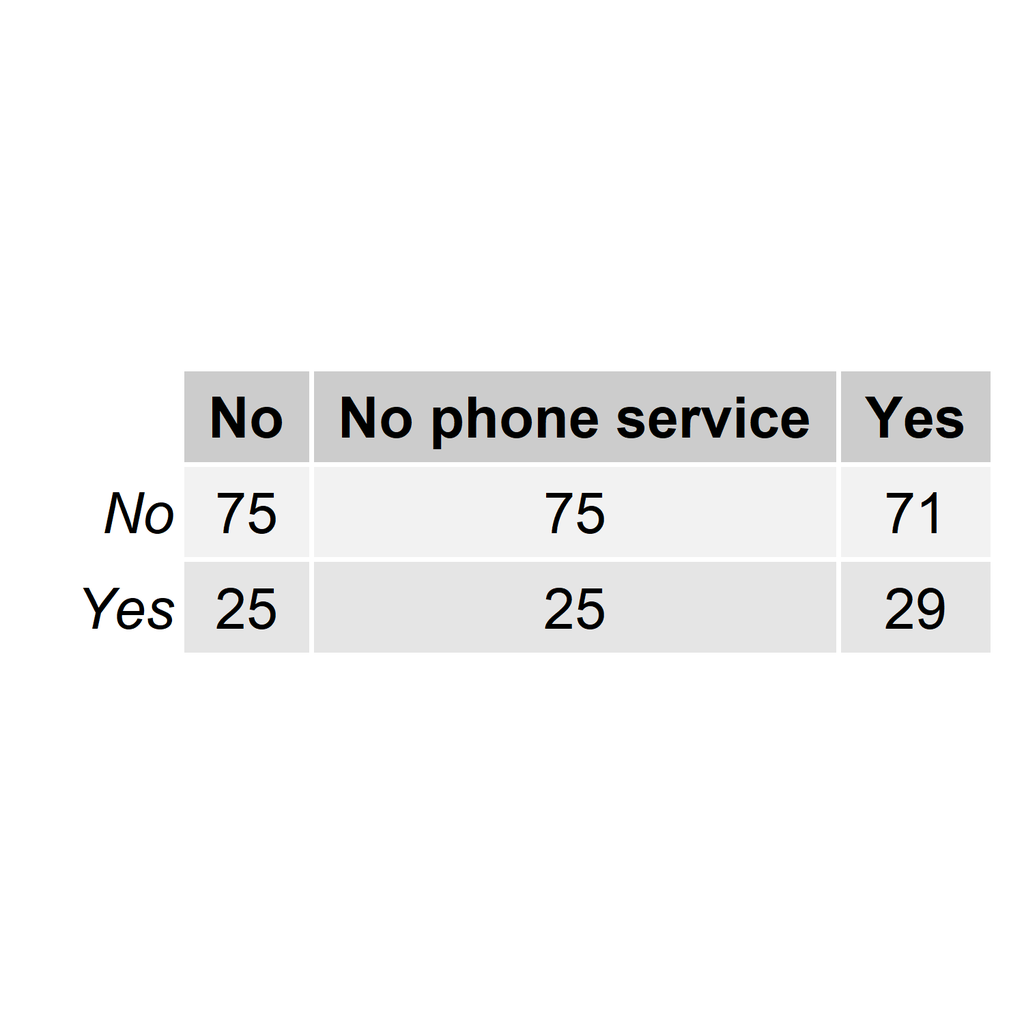

#### 2.3.4 Variables relacionadas al servicio de Internet

- Se observa que los que no contratan servicio de internet tienen una tasa de abandono muy baja y que entre los que contratan servicio de Internet, los que más desertan son los que contratan Fibra Óptica (42%).
- Los clientes que contratan Internet pero no `OnlineBackUp` tienen una tasa de abandono del 40%. Un comportamiento similar se observa en los clientes que contratan Internet pero no `DeviceProtection`.
- En relación al servicio de Streaming, se observa que los clientes que contratan Internet pero no el servicio de Streaming (tanto TV como movies) tienen un porcentaje de abandono mayor (34%).
- Los clientes que contratan Internet pero no `TechSupport` tienen una tasa de abandono del 40%. Un comportamiento similar se observa en los clientes que contratan Internet pero no `OnlineSecurity`.

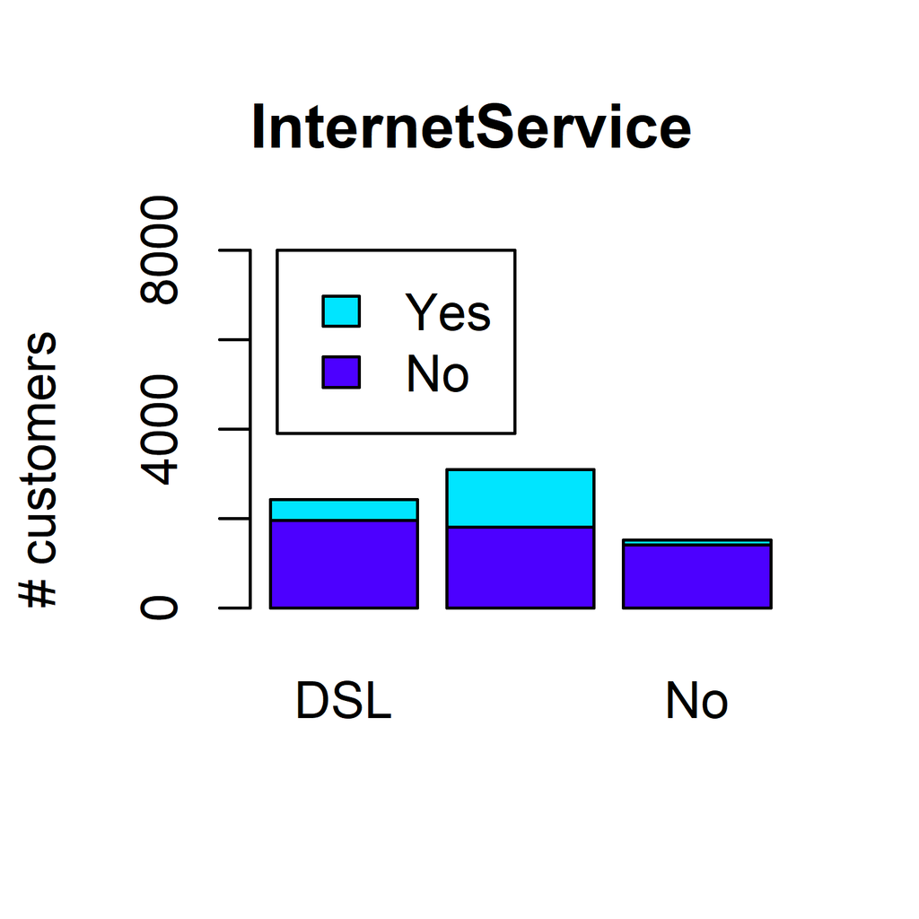

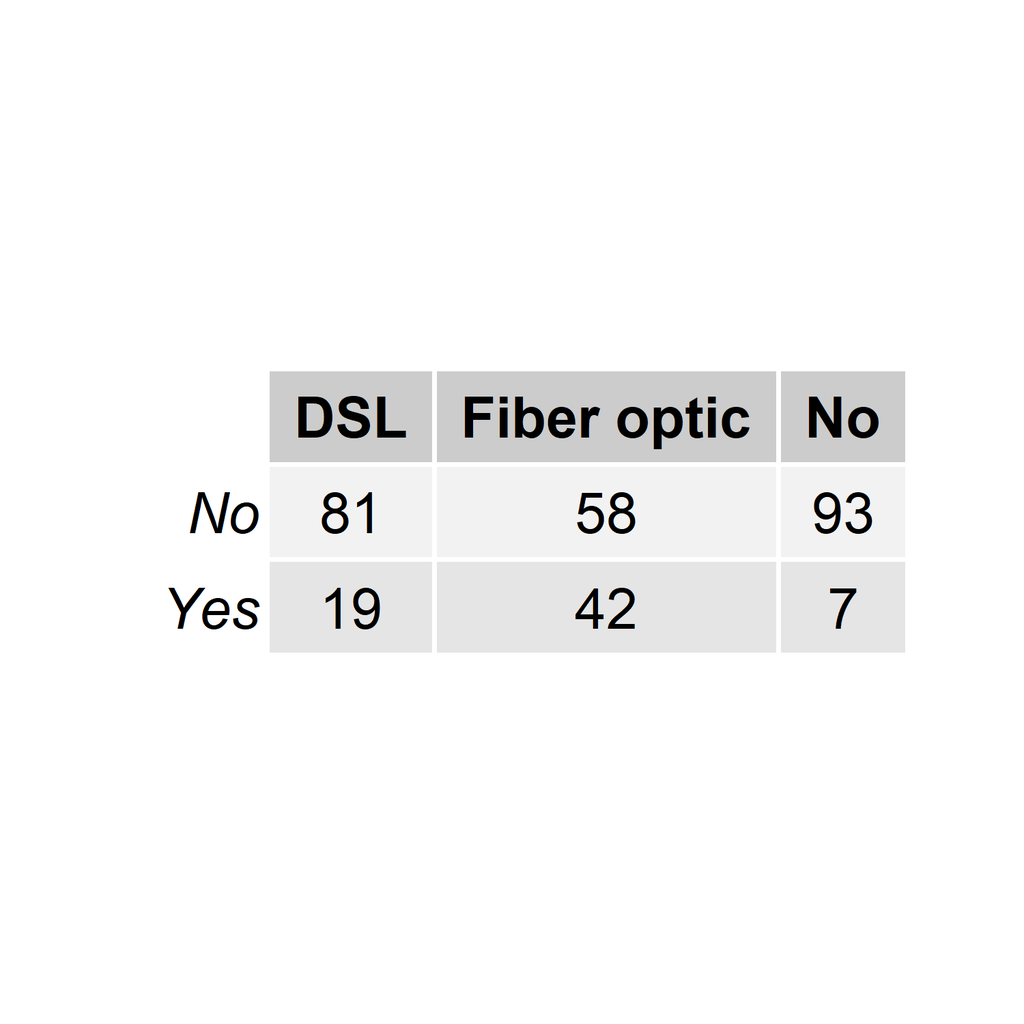

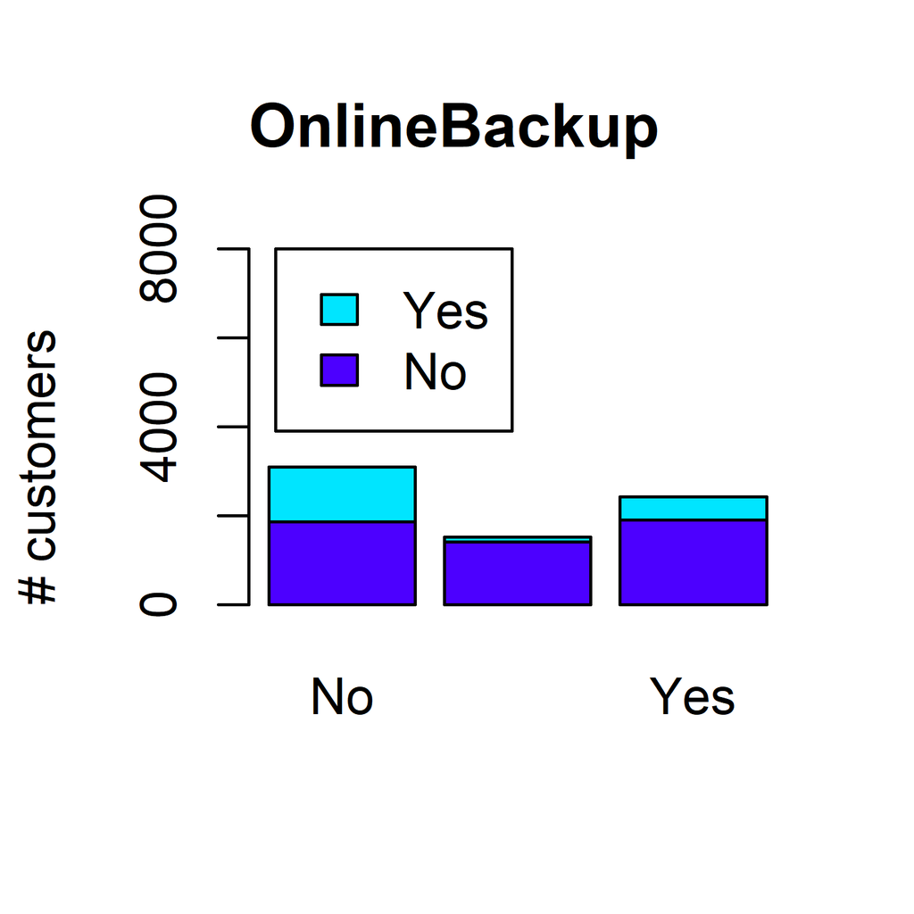

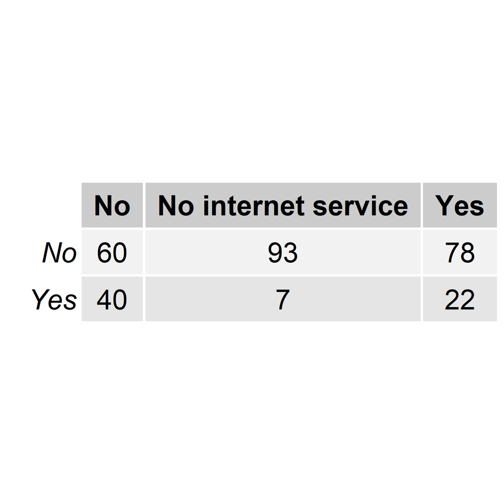

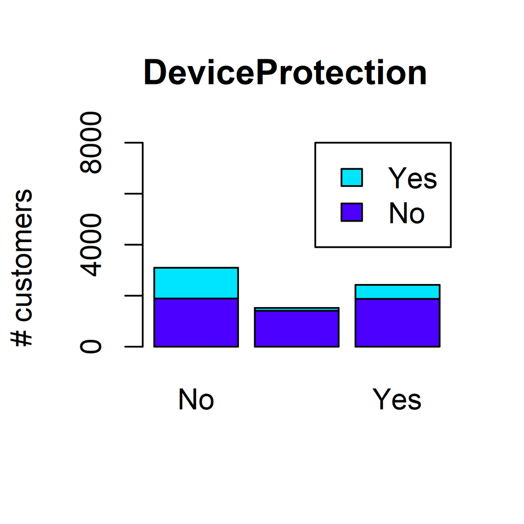

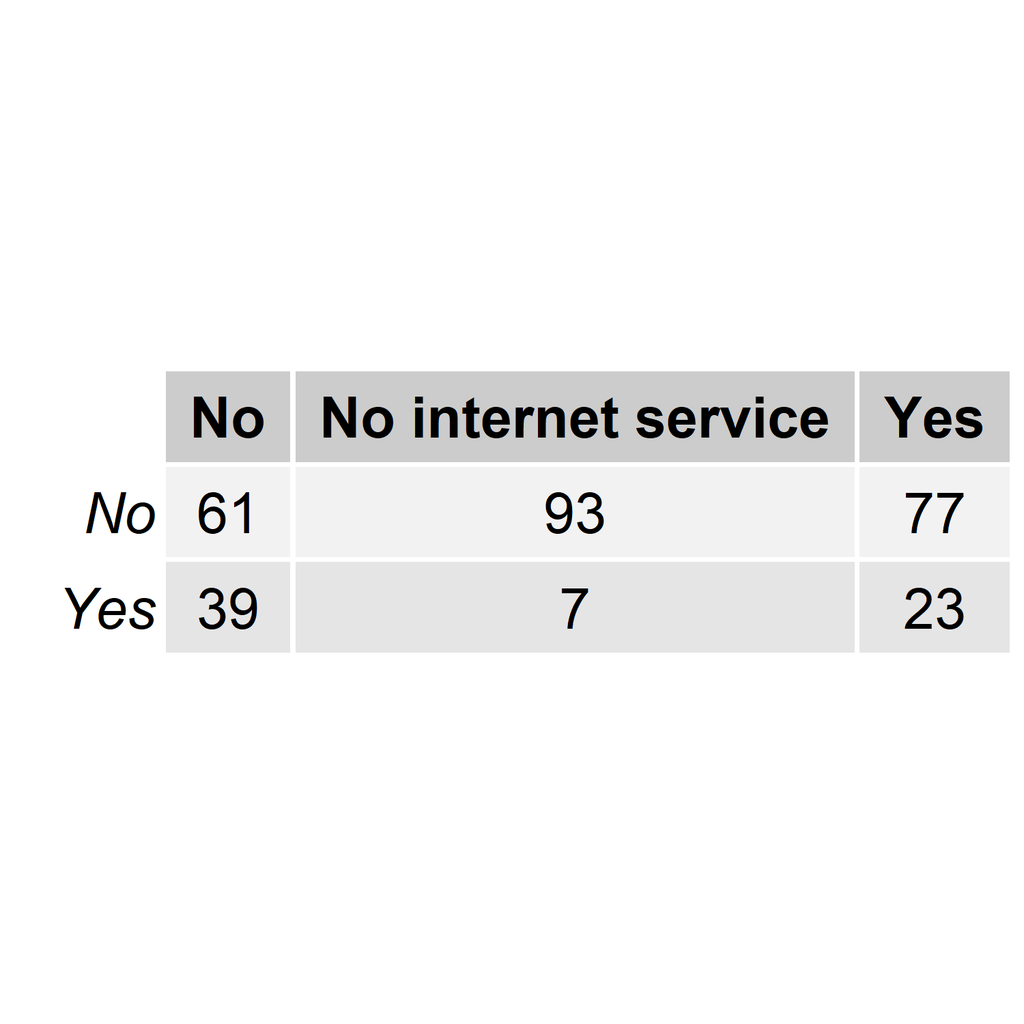

[figure not shown]

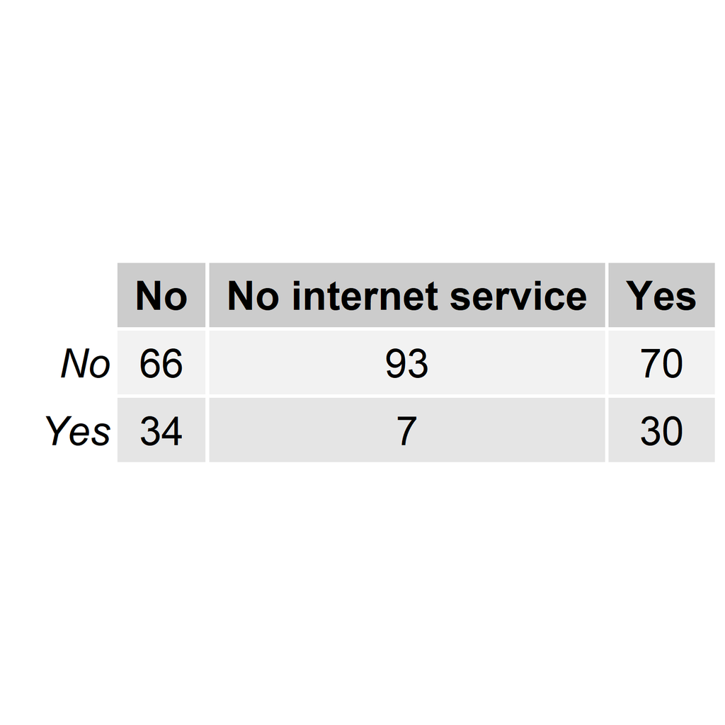

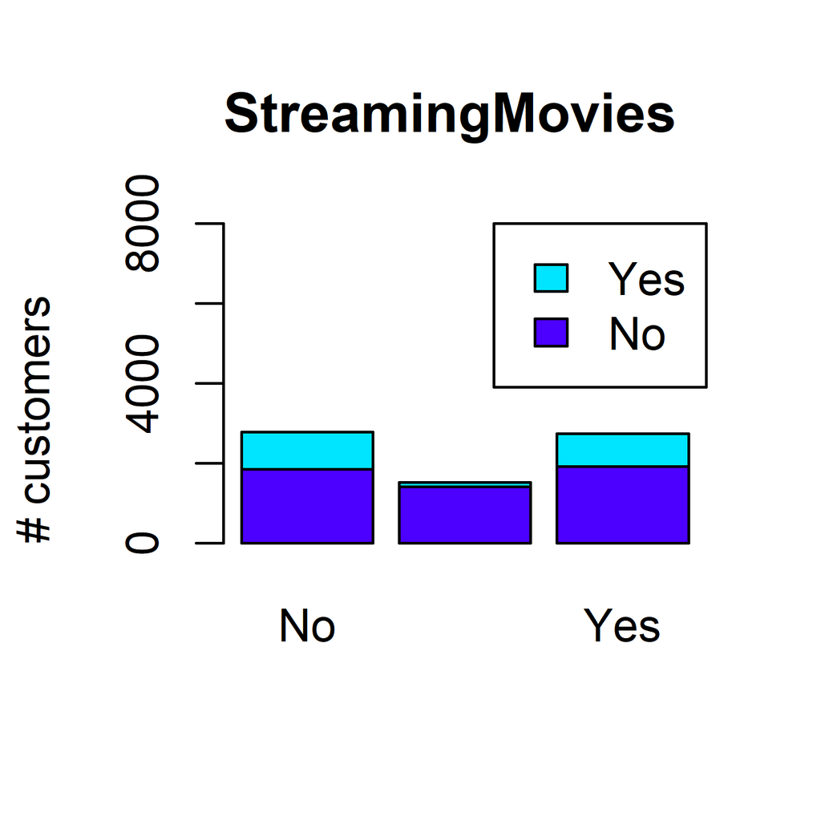

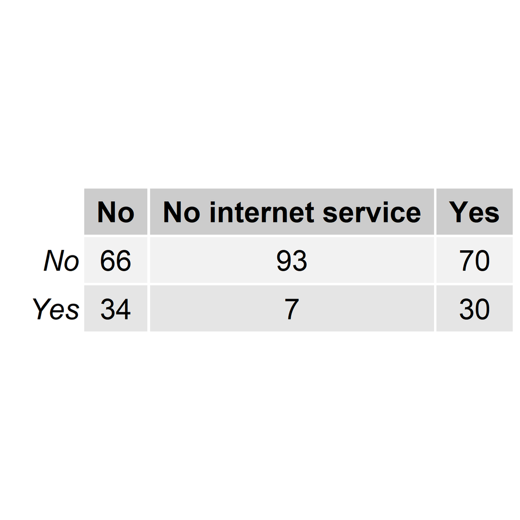

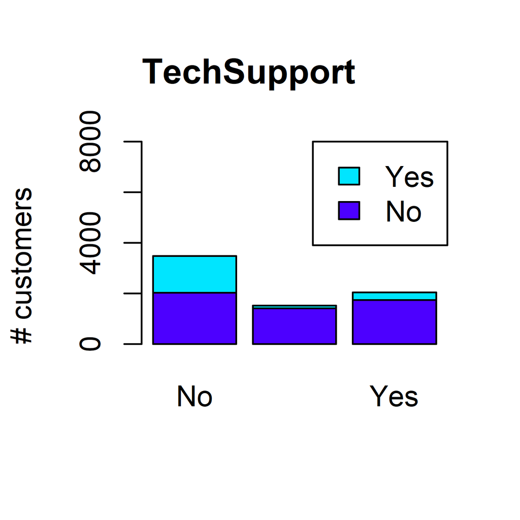

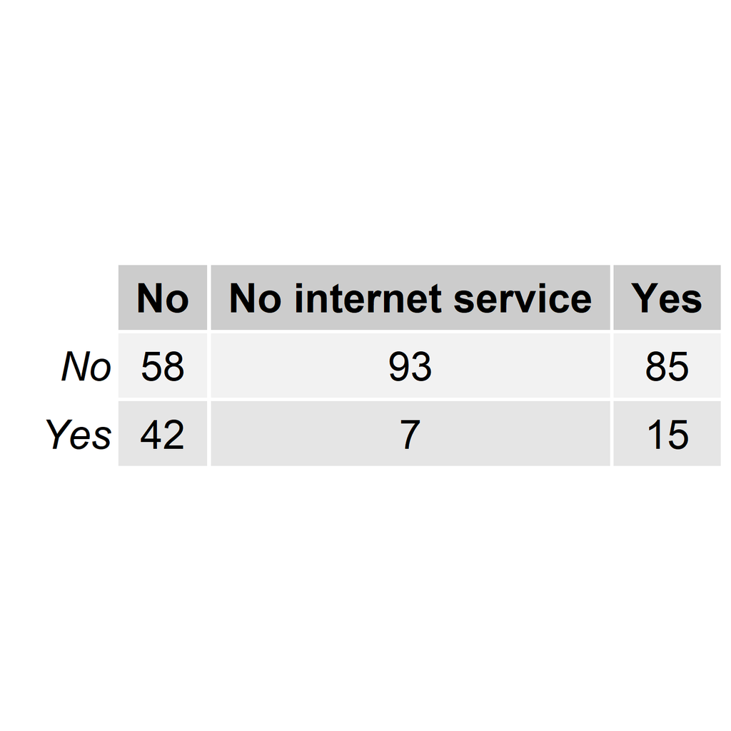

[2 more figures not shown]

## 3. Preprocesamiento

#### 3.1. Eliminación de la variable `customerID`

Dado que `customerID` es una variable que no tiene poder predictor, ya que se utiliza solamente para identificar a los clientes, ha sido eliminada.

```r
customer <- customer[,-1]
```

#### 3.2. Conversión del tipo de la variable `SeniorCitizen` a factor

Por otro lado, la variable `SeniorCitizen` debería ser de tipo factor.

```r
customer$SeniorCitizen <- as.factor(customer$SeniorCitizen)
```

#### 3.3 Recodificación de las variables relacionadas al servicio de teléfono e Internet

Como la información relacionada a la no contratación de los servicios de teléfono e Internet se encuentra en las variables `PhoneService` e `InternetService`, respectivamente, se unificaron las categorías `No phone/internet service` y `No` de esas variables. De esta manera se ha conseguido evitar que hubiera variables idénticas luego de la conversión de las variables categóricas a variables dummy.

```r
customer$MultipleLines <- as.factor(Recode(customer$MultipleLines,
                                        "'No phone service' = 'No'"))
customer$OnlineSecurity <- as.factor(Recode(customer$OnlineSecurity,
                                        "'No internet service' = 'No'"))
customer$OnlineBackup <- as.factor(Recode(customer$OnlineBackup,
                                        "'No internet service' = 'No'"))
customer$DeviceProtection <- as.factor(Recode(customer$DeviceProtection,
                                        "'No internet service' = 'No'"))
customer$TechSupport <- as.factor(Recode(customer$TechSupport,
                                        "'No internet service' = 'No'"))
customer$StreamingTV <- as.factor(Recode(customer$StreamingTV,
                                        "'No internet service' = 'No'"))
customer$StreamingMovies <- as.factor(Recode(customer$StreamingMovies,
                                        "'No internet service' = 'No'"))
```

#### 3.4. Transformación de las variables categóricas a dummy

Por último, como hay modelos que no aceptan variables categóricas como variables de entrada, se las ha transformado a variables dummy.

```r
dummies <- dummyVars(Churn~., data=customer, fullRank = TRUE)
dummy_mat <- predict(dummies, newdata=customer)
customer.dummy <- data.frame(dummy_mat, Churn=customer$Churn)
```

#### 3.5. División del dataset en Train y Test

Para realizar la división del dataset en Train y Test, se ha indicado que el dataset de Train tuviera un 66% de las instancias del dataset original.

```r
set.seed(123)
trainIndex <- createDataPartition(customer.dummy$Churn,
                                  p = 0.66,
                                  list = FALSE,
                                  times = 1)
customerTrain <- customer.dummy[trainIndex,]
customerTest <- customer.dummy[-trainIndex,]
```

Los nombres de las variables del dataset definitivo fueron:

```r
names(customerTrain)
```

```
##  [1] "gender.Male"
##  [2] "SeniorCitizen.1"
##  [3] "Partner.Yes"
##  [4] "Dependents.Yes"
##  [5] "tenure"
##  [6] "PhoneService.Yes"
##  [7] "MultipleLines.Yes"
##  [8] "InternetService.Fiber.optic"
##  [9] "InternetService.No"
## [10] "OnlineSecurity.Yes"
## [11] "OnlineBackup.Yes"
## [12] "DeviceProtection.Yes"
## [13] "TechSupport.Yes"
## [14] "StreamingTV.Yes"
## [15] "StreamingMovies.Yes"
## [16] "Contract.One.year"
## [17] "Contract.Two.year"
## [18] "PaperlessBilling.Yes"
## [19] "PaymentMethod.Credit.card..automatic."
## [20] "PaymentMethod.Electronic.check"
## [21] "PaymentMethod.Mailed.check"
## [22] "MonthlyCharges"
## [23] "TotalCharges"
## [24] "Churn"
```

### 3.6 Decisión de no practicar un balanceo en el dataset de Train

A pesar de que las clases de la variable a predecir están desbalanceadas se decidió no hacer un proceso de balanceo, dado que no mejora la performance en términos de Accuracy. Dicho de otro modo, se realizó y se consiguieron valores más bajos de Accuracy en el conjunto de Test. Al final de este documento, se recogen los valores de esta y otras métricas en el conjunto de Test para los modelos entrenados con el dataset balanceado (upsampling) y sin balancear.

## 4. Selección de variables

El dataset generado cuenta con 23 variables predictoras. Se ha realizado una selección a través de una eliminación recursiva de variables. Para ello, se ha utilizado el dataset de Train, el clasificador usado ha sido Random Forest y se ha hecho cross-validation con 5 pliegues.

Al final de este documento se recogen los valores de Accuracy y otras métricas sobre el conjunto de Test para los modelos entrenados con el dataset generado hasta aquí y con el dataset obtenido luego de hacer la selección de variables.

```r
subsets <- c(3:length(names(customerTrain)))
set.seed(123)
seeds <- vector(mode = "list", length = 6)
for(i in 1:5) seeds[[i]] <- sample.int(1000, length(subsets) + 1)
seeds[[6]] <- sample.int(1000, 1)

ctrl.rfe <- rfeControl(functions=rfFuncs,
                       method = "cv",
                       number = 5,
                       seeds = seeds,
                       returnResamp="final",
                       verbose = TRUE,
                       allowParallel = TRUE)
set.seed(342)
rf.rfe <- rfe(Churn~., data=customerTrain,
              sizes=subsets,
              rfeControl=ctrl.rfe)

saveRDS(rf.rfe, "rf.rfe.rds")
```

Como resultado, han sido seleccionadas las siguientes variables tanto en el dataset de Train como en el de Test:

```r
rf.rfe$optVariables
```

```
##  [1] "tenure"                         "TotalCharges"
##  [3] "InternetService.Fiber.optic"    "MonthlyCharges"
##  [5] "Contract.Two.year"              "Contract.One.year"
##  [7] "InternetService.No"             "TechSupport.Yes"
##  [9] "OnlineSecurity.Yes"             "PaperlessBilling.Yes"
## [11] "PaymentMethod.Electronic.check" "OnlineBackup.Yes"
## [13] "StreamingMovies.Yes"            "MultipleLines.Yes"
## [15] "PhoneService.Yes"
```

```r
sel.cols <- c(rf.rfe$optVariables,"Churn")
dataset.train <- customerTrain[,sel.cols]
dataset.test <- customerTest[,sel.cols]
```

## 5. Entrenamiento

En los 5 casos que siguen, en el objeto control se indicó que se iría a realizar validación cruzada con 10 pliegues.

### 5.1 Rpart

El primer modelo que se probó fue `rpart`, que genera un árbol de decisión. El hiperparámetro que se puede modificar utilizando el paquete `caret` es el `cp` (complexity parameter) y los valores que iría a tomar se indicaron a través de una grilla en la función `train()`.

```r
grid <- expand.grid(cp=seq(1,150,3)/1000)

set.seed(123)
seeds <- sample.int(1000,11)

fit.control.cv.10 <- trainControl(method = "cv", number=10,
                                  seeds = seeds,
                                  returnResamp = "all",
                                  verboseIter=FALSE,
                                  allowParallel = TRUE)

set.seed(342)
rpart.cv.10 <- train(Churn~.,data=dataset.train,
                     method="rpart",
                     tuneGrid=grid,
                     trControl=fit.control.cv.10)
saveRDS(rpart.cv.10, "rpart.cv.10.rds")
```

Como se puede ver en el gráfico siguiente, el mejor Accuracy obtenido fue 0.7927638 y se consiguió utilizando un valor de `cp` igual a 0.103.

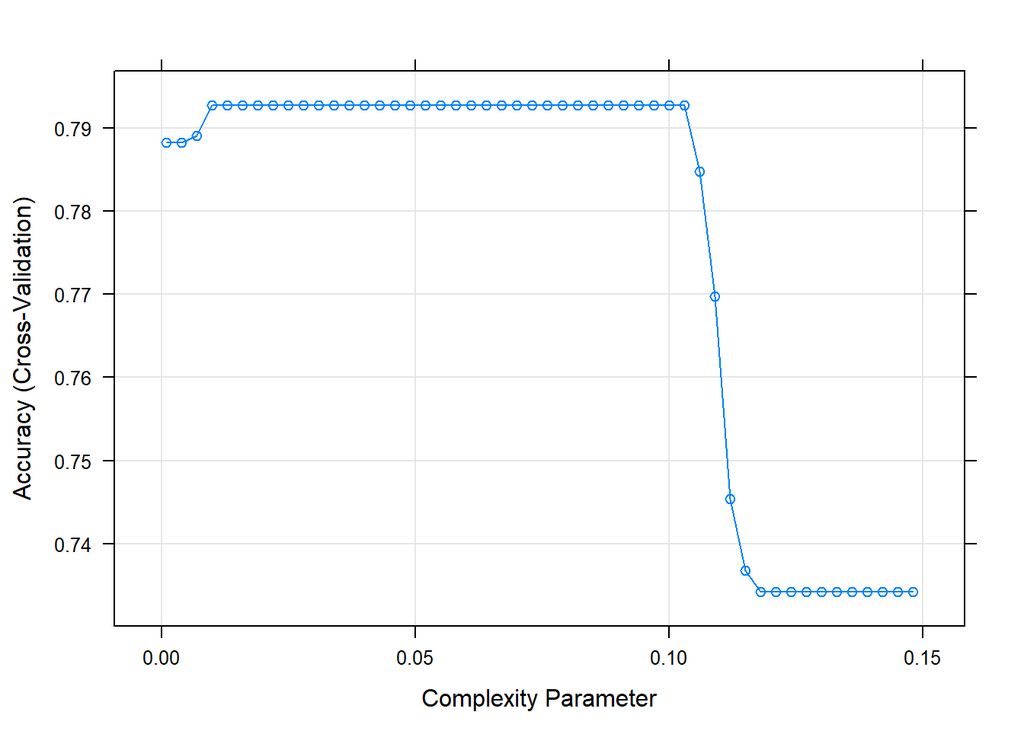

A continuación, se muestra el árbol de decisión generado. Como se puede ver, las variables utilizadas para su construcción fueron `tenure` y `InternetService.Fiber.optic`.

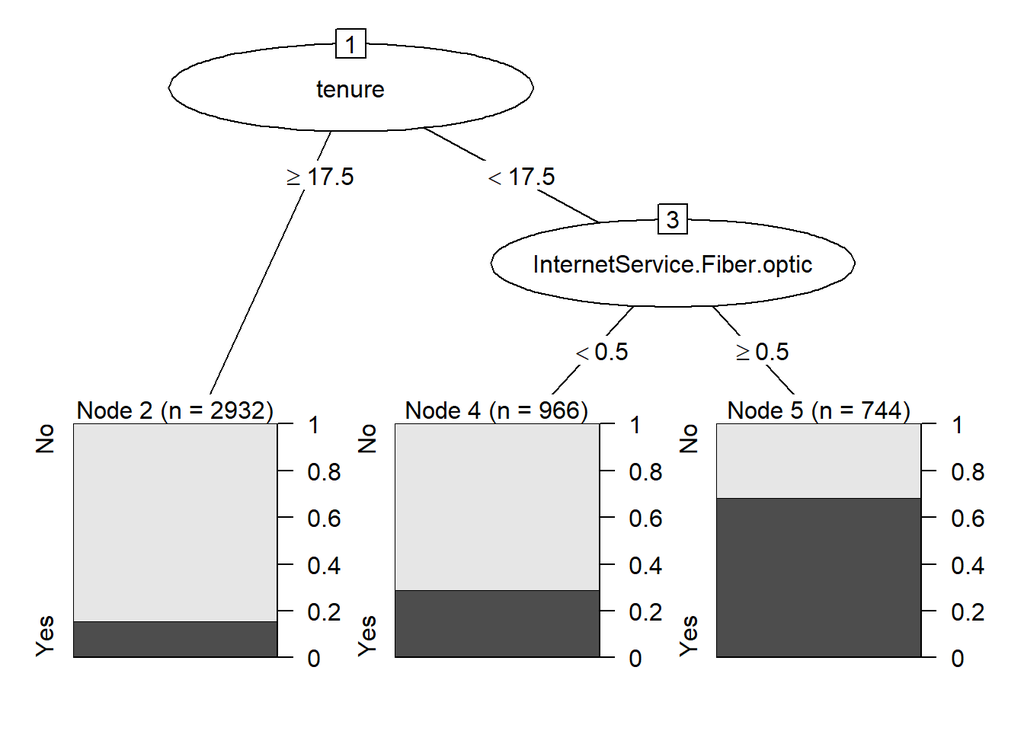

### 6.2 Random forest

El siguiente método probado fue Random Forest. El hiperparámetro a modificar fue `mtry`, que indica cuántas variables se consideran candidatas para hacer cada split.

```r
grid <- expand.grid(mtry=c(1,2,3,4,5,6,7,8,9,10))

set.seed(123)
seeds <- vector(mode = "list", length = 11)
for(i in 1:10) seeds[[i]] <- sample.int(1000, 10)
seeds[[11]] <- sample.int(1000, 1)


fit.control.cv.10.rf <- trainControl(method = "cv",number=10,
                                      seeds = seeds,
                                      returnResamp = "all",
                                      verboseIter=FALSE,
                                      allowParallel = TRUE)

set.seed(342)
rf.cv.10 <- train(Churn~.,data=dataset.train,
                   method="rf",
                   tuneGrid=grid,
                   trControl = fit.control.cv.10.rf)
saveRDS(rf.cv.10, "rf.cv.10.rds")
```

Como se puede ver en el gráfico siguiente, el mejor Accuracy obtenido fue 0.8059057 y se consiguió utilizando un valor de `mtry` igual a 2.

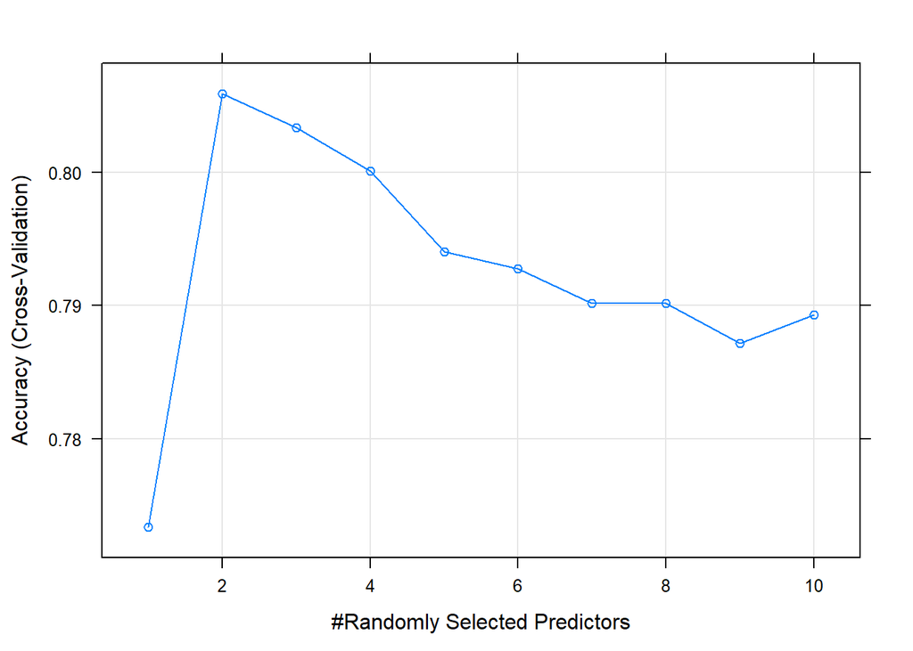

Por último, es interesante observar la importancia de las variables calculada por este método. Las variables con más importancia resultaron ser las cuantitativas, seguidas por `InternetService.Fiber.optic`, `Contract.Two.Year` y `PaymentMethod.Electronic.check`.

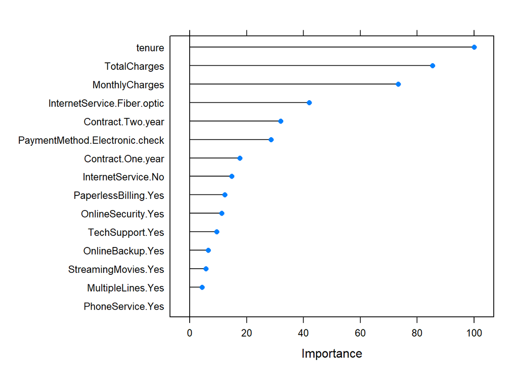

### 6.3 Linear discriminant analysis

El tercer método es Linear Discriminant Analysis. Es aconsejable centrar y escalar los datos antes de entrenar el modelo y es por esto que en la función `train()` se indicó que se hicieran estas dos transformaciones. A diferencia de los otros dos métodos, este no tiene hiperparámetros para modificar.

```r
set.seed(123)
seeds <- vector(mode = "list", length = 11)
for(i in 1:10) seeds[[i]] <- sample.int(1000, 144)
seeds[[11]] <- sample.int(1000, 1)


fit.control.cv.10.lda <- trainControl(method = "cv",number = 10,
                                       seeds = seeds,
                                       returnResamp = "all",
                                       verboseIter = FALSE,
                                       allowParallel = TRUE)
set.seed(342)
lda.cv.10 <- train(Churn~.,data=dataset.train,
                    method="lda",
                    preProc=c("center", "scale"),
                    trControl=fit.control.cv.10.lda)
saveRDS(lda.cv.10, 'lda.cv.10.rds')
```

### 6.4 svmRadial

El cuarto modelo es Support Vector Machine con kernel radial. Los hiperparámetros con los que se puede experimentar son dos: sigma y C. En este caso también es necesario centrar y escalar los datos, pero el método lo hace por defecto, por lo que no es necesario indicarlo en la función `train`.

```r
grid <- expand.grid(sigma=c(0.001, 0,01, 0,1, 1, 100, 1000),
                    C=c(0.25, 0.5, 1, 2, 4, 8, 16, 32, 64, 128))


set.seed(123)
seeds <- vector(mode = "list", length = 11)
for(i in 1:10) seeds[[i]] <- sample.int(1000, 50)
seeds[[11]] <- sample.int(1000, 1)

svmRadial.control.cv.10 <- trainControl(method = "cv", number=10,
                                  seeds = seeds,
                                  returnResamp = "all",
                                  verboseIter=FALSE,
                                  allowParallel = TRUE)

set.seed(342)
svmradial.cv.10 <- train(Churn~.,data=dataset.train,
                     method="svmRadial",
                     tuneGrid=grid,
                     trControl=svmRadial.control.cv.10)
saveRDS(svmradial.cv.10, 'svmradial.cv.10.rds')
```

Como se puede ver en el gráfico siguiente, los mayores Accuracy se obtuvieron con `sigma` igual a 0.001. El mejor Accuracy fue 0.8039647 y se consiguió utilizando `C` igual a 64.

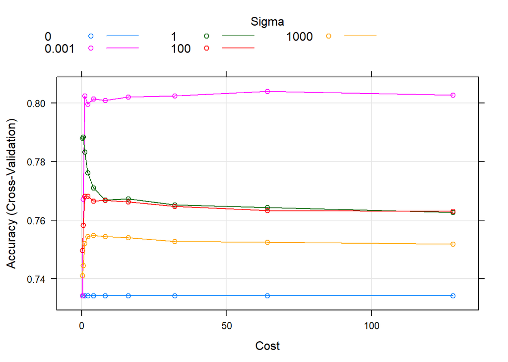

### 6.5 AdaBoost

El último método a probar fue AdaBoost. Los hiperparámetros que toma son tres: `nu` (similar a una tasa de aprendizaje), `iter` (cantidad de árboles que se van a entrenar) y `maxdepth` (la profundidad máxima que puede alcanzar cada árbol).

```r
grid <- expand.grid(maxdepth=c(1,2,3,4,5,6),
                    iter=c(50, 150, 250, 350, 450, 550),
                    nu=c(0.1, 0.2))
set.seed(123)
seeds <- vector(mode = "list", length = 11)
for(i in 1:10) seeds[[i]] <- sample.int(1000,  12)
seeds[[11]] <- sample.int(1000, 1)
ada.control <- trainControl(method = "cv", number=10,
                            seeds = seeds,
                            returnResamp = "all",
                            verboseIter=FALSE,
                            allowParallel = TRUE)
set.seed(342)
ada.cv.10 <- train(Churn~.,data=dataset.train,
                   method="ada",
                   tuneGrid=grid,
                   trControl=ada.control)
saveRDS(ada.cv.10, 'ada.cv.10.rds')
```

Como se puede ver en el gráfico siguiente, el mejor Accuracy fue 0.8063308 y se obtuvo con `nu` igual a 0.2, `maxdepth` igual a 1 y `iter` igual a 550.

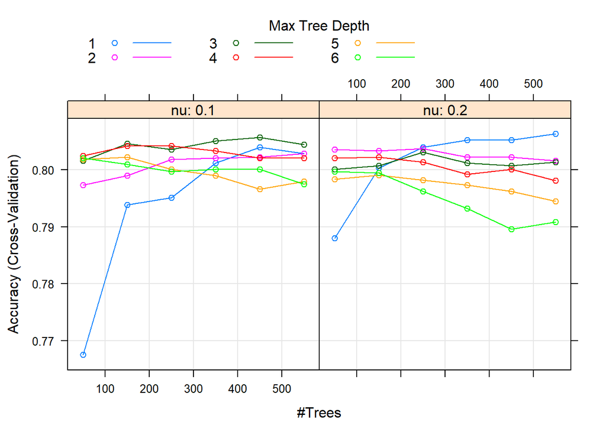

## 7. Comparación de los clasificadores

Para comparar los 5 clasificadores se calculó la diferencia entre modelos y se realizó la prueba T de Student para evaluar la hipótesis nula de que no hay diferencias entre los mismos.

```
##
## Call:
## summary.diff.resamples(object = difValues)
##
## p-value adjustment: bonferroni
## Upper diagonal: estimates of the difference
## Lower diagonal: p-value for H0: difference = 0
##
## Accuracy
##           Rpart     SVMRadial AdaBoost  RF        LDA
## Rpart               -0.011201 -0.013567 -0.013142 -0.007966
## SVMRadial 0.0001673           -0.002366 -0.001941  0.003235
## AdaBoost  0.0832841 1.0000000            0.000425  0.005601
## RF        0.0120288 1.0000000 1.0000000            0.005176
## LDA       0.9354323 1.0000000 1.0000000 1.0000000
##
## Kappa
##           Rpart     SVMRadial AdaBoost  RF        LDA
## Rpart               -0.061109 -0.073948 -0.069960 -0.077246
## SVMRadial 2.337e-06           -0.012839 -0.008851 -0.016137
## AdaBoost  0.0011321 1.0000000            0.003988 -0.003298
## RF        0.0001385 1.0000000 1.0000000           -0.007286
## LDA       0.0004630 1.0000000 1.0000000 1.0000000
```

Se puede observar que podemos rechazar la hipótesis de que lo modelos presentan la misma Accuracy (las medias son iguales H0:μ0=μ1), al haber p-values menores que la signicancia por defecto 0.05.

Considerando al Accuracy, se puede decir que hay diferencias entre `Rpart y Random Forest` y entre `Rpart y svmRadial`.

En el siguiente gráfico se muestra un gráfico de cajas para el `Accuracy` y el `índice Kappa` de cada clasificador.

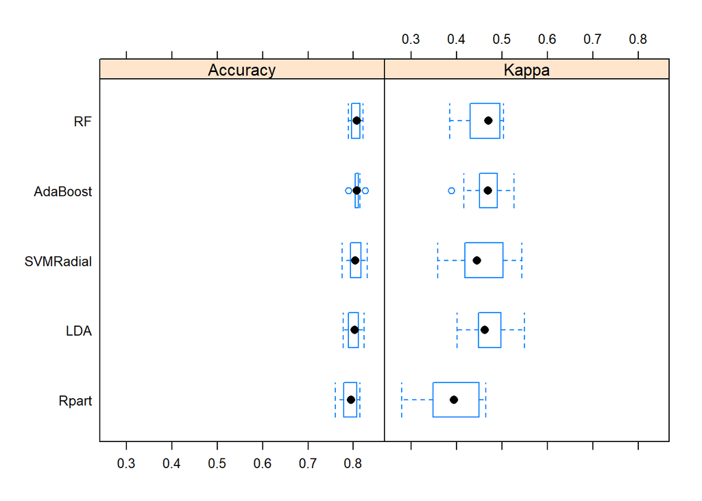

## 8. Evaluación de los clasificadores en el conjunto de Test

Finalmente, se evaluaron los clasificadores en el conjunto de Test.

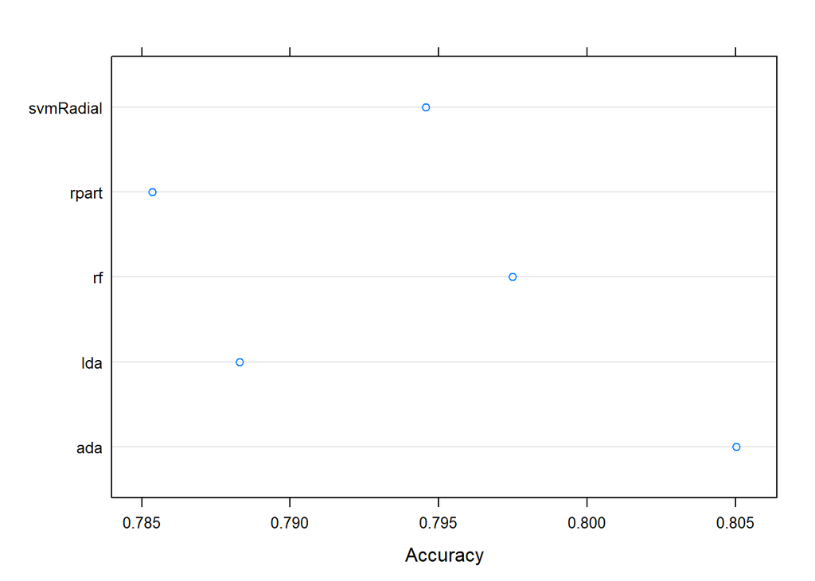

|  | Accuracy | Kappa | Sensitivity | Specifity |
| --- | --- | --- | --- | --- |
| rpart | 0.785 | 0.371 | 0.398 | 0.925 |
| adaBoost | 0.805 | 0.464 | 0.528 | 0.905 |
| svmRadial | 0.795 | 0.419 | 0.466 | 0.913 |
| LDA | 0.788 | 0.434 | 0.537 | 0.879 |
| Random Forest | 0.797 | 0.440 | 0.507 | 0.902 |

Como puede apreciarse, el modelo que más eficacia tiene ,medida en términos de `Accuracy`, fue `adaBoost` (**0.805**), seguido por `Random Forest` (**0.797**) y `svmRadial` (**0.795**). Teniendo en cuenta que con el clasificador más simple (naive classifier) se obtendría un 0.73 de `Accuracy`, podemos decir que estos clasificadores lo superan en performance, pero no en gran medida.

Con respecto a la sensibilidad (proporción de clientes correctamente detectados como `Churn=Yes`), podemos decir que `LDA` resultó ser el mejor (0.537).

Con respecto a la especificidad (proporción de clientes correctamente detectados como `Churn=No`), podemos decir que `rpart` resultó ser el mejor (0.925).

### Comparación de resultados obtenidos utilizando el dataset original

|  | Accuracy | Kappa | Sensitivity | Specifity |
| --- | --- | --- | --- | --- |
| rpart | 0.785 | 0.371 | 0.398 | 0.925 |
| adaBoost | 0.803 | 0.466 | 0.545 | 0.896 |
| svmRadial | 0.797 | 0.435 | 0.491 | 0.908 |
| LDA | 0.791 | 0.437 | 0.532 | 0.884 |
| Random Forest | 0.797 | 0.423 | 0.466 | 0.916 |

Al comparar los resultados obtenidos en el conjunto de Test tras haber eliminado el proceso de selección de variables, se observan resultados similares a los mostrados anteriormente.  
Más detalle de este análisis en el archivo GonzalezGiaimoLucia_sinSeleccion.rmd.

### Comparación de resultados obtenidos incluyendo un balanceo en el dataset de entrenamiento (upsampling) y haciendo selección de variables

|  | Accuracy | Kappa | Sensitivity | Specifity |
| --- | --- | --- | --- | --- |
| rpart | 0.745 | 0.429 | 0.746 | 0.745 |
| adaBoost | 0.768 | 0.459 | 0.718 | 0.786 |
| svmRadial | 0.739 | 0.084 | 0.087 | 0.975 |
| LDA | 0.740 | 0.435 | 0.792 | 0.721 |
| Random Forest | 0.779 | 0.434 | 0.586 | 0.849 |

Más detalle de este análisis en el archivo GonzalezGiaimoLucia_conBalanceo.rmd.